# Исследование сетевых параметров публичных DNS серверов

## Цель работы

Проанализировать сетевые параметры публичных DNS серверов, сделать мотивированный вывод о предпочтительных серверах

## ️Используемое ПО

1. Rstudio IDE
2. `traceroute/tracert`
3. `ping`
4. `whois`

## Исследуемые провайдеры DNS

```
1. Google Public DNS
2. Cloudflare DNS
3. OpenDNS
4. DNS вашего провайдера
```

## Ход работы

1. По исследуемым серверам собрать следующие данные:
   - маршрут
   - местоположение каждого узла маршрута к DNS-серверу
   - организацию, владеющую каждым узлом маршрута к DNS-серверу
   - среднюю RTT к DNS-серверу
2. Выделить те узлы маршрута, которые вносят наибольшую временную задержку при передаче
3. Сравнить сетевые параметры DNS серверов

## Решение поставленнной цели

**Google Public DNS** - интернет-сервис корпорации Google, предоставляющий общедоступные DNS-серверы. Открыт в декабре 2009 года. По словам компании, обеспечивает ускорение загрузки веб-страниц за счет повышения эффективности кэширования данных, а также улучшенную защиту от спуфинга.

```python
!chcp 65001
```

```
Active code page: 65001
```

```python
!tracert 8.8.8.8
```

```
Tracing route to dns.google [8.8.8.8]
over a maximum of 30 hops:

  1     1 ms     1 ms    <1 ms  192.168.0.1
  2     1 ms     1 ms     1 ms  172.18.0.1
  3     2 ms     1 ms     1 ms  gw-core.gptel.ru [77.73.25.1]
  4     2 ms     2 ms     1 ms  77.94.162.77
  5     1 ms     1 ms     2 ms  ae3-nostromo-mtt-msk.naukanet.ru [77.94.160.52]
  6     8 ms     4 ms     4 ms  209.85.148.20
  7     2 ms     2 ms     2 ms  108.170.250.66
  8    19 ms    19 ms    20 ms  209.85.255.136
  9    48 ms    20 ms    17 ms  216.239.54.50
 10     *        *        *     Request timed out.
 11     *        *        *     Request timed out.
 12     *        *        *     Request timed out.
 13     *        *        *     Request timed out.
 14     *        *        *     Request timed out.
 15     *        *        *     Request timed out.
 16     *        *        *     Request timed out.
 17     *        *        *     Request timed out.
 18     *        *        *     Request timed out.
 19    19 ms    18 ms    20 ms  dns.google [8.8.8.8]

Trace complete.
```

RTT = 19 ms

[output not shown]

**Cloudflare** — американская компания, предоставляющая услуги CDN, защиту от DDoS-атак, безопасный доступ к ресурсам и серверы DNS.

```python
!tracert 1.1.1.1
```

```
Tracing route to one.one.one.one [1.1.1.1]
over a maximum of 30 hops:

  1    <1 ms    <1 ms    <1 ms  192.168.0.1
  2     2 ms    <1 ms    <1 ms  172.18.0.1
  3     2 ms     1 ms     1 ms  gw-core.gptel.ru [77.73.25.1]
  4     1 ms     1 ms     1 ms  gptel145.cln.net [79.98.8.145]
  5     2 ms     2 ms     2 ms  jun0-mr-vl7.cln.net [79.98.8.254]
  6    19 ms    19 ms    19 ms  netnod-ix-ge-a-sth-1500.cloudflare.com [194.68.123.246]
  7    20 ms    19 ms    19 ms  one.one.one.one [1.1.1.1]

Trace complete.
```

RTT = 19

| Узел | Месторасположение | Организация |
| --- | --- | --- |
| 192.168.0.1 | Москва | Домашний роутер |
| 172.18.0.1 | Москва | Гран При Телеком |
| gw-core.gptel.ru [77.73.25.1] | Москва | Гран При Телеком |
| gptel145.cln.net [79.98.8.145] | Москва | CLN |
| jun0-mr-vl7.cln.net [79.98.8.254] | Москва | CLN |
| netnod-ix-ge-a-sth-1500.cloudflare.com [194.68.123.246] | Borgholm, Sweden | Stockholm Interconnect GigEth |
| one.one.one.one [1.1.1.1] | Research, Australia | Cloudflare DNS |

**OpenDNS** — интернет-служба, предоставляющая общедоступные DNS-серверы. Имеет платный и бесплатный режим, может исправлять опечатки в набираемых адресах, фильтровать фишинговые сайты, в случае набора неправильных запросов может предлагать страницу с поиском и рекламой.

```python
!tracert 208.67.220.220
```

```
Tracing route to resolver2.opendns.com [208.67.220.220]
over a maximum of 30 hops:

  1    <1 ms    <1 ms    <1 ms  192.168.0.1
  2     1 ms     1 ms     1 ms  172.18.0.1
  3     1 ms     1 ms     1 ms  gw-core.gptel.ru [77.73.25.1]
  4     1 ms     2 ms     1 ms  gptel145.cln.net [79.98.8.145]
  5     3 ms     1 ms     1 ms  jun0-mr-vl7.cln.net [79.98.8.254]
  6     2 ms     1 ms     1 ms  ae11-747.RT.MR.MSK.RU.retn.net [87.245.253.18]
  7    76 ms    39 ms    40 ms  ae3-8.RT.TC2.AMS.NL.retn.net [87.245.233.17]
  8    47 ms    47 ms    53 ms  peer1.rtr1.ams.opendns.com [80.249.208.88]
  9    45 ms    47 ms    47 ms  resolver2.opendns.com [208.67.220.220]

Trace complete.
```

RTT = 46

[output not shown]

**Гран При Телеком** - оператор услуг связи, поставщик и интегратор АТС оборудования.

```python
!tracert 77.73.24.2
```

```
Tracing route to ns.gptel.ru [77.73.24.2]
over a maximum of 30 hops:

  1     1 ms     1 ms     1 ms  192.168.0.1
  2     2 ms     1 ms     1 ms  172.18.0.1
  3     1 ms     1 ms     1 ms  gw-aggr1.gptel.ru [77.73.25.6]
  4     1 ms     1 ms     1 ms  ns.gptel.ru [77.73.24.2]

Trace complete.
```

RTT = 1

| Узел | Месторасположение | Организация |
| --- | --- | --- |
| 192.168.0.1 | Москва | Домашний роутер |
| 172.18.0.1 | Москва | Гран При Телеком |
| gw-aggr1.gptel.ru [77.73.25.6] | Москва | Гран При Телеком |
| ns.gptel.ru [77.73.24.2] | Москва | network for GRANDPRIX Telecom |

**График распределения времени до DNS - серверов**

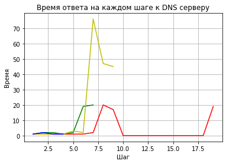

```python
import matplotlib.pyplot as plt
plt.title("Время ответа на каждом шаге к DNS серверу")
plt.xlabel("Шаг")
plt.ylabel("Время") # ось ординат
plt.plot([1,2,3,4,5,6,7,8,9,10,11,12,13,14,15,16,17,18,19],[1,1,1,1,1,1,2,20,17,0,0,0,0,0,0,0,0,0,19],'r')
plt.plot([1,2,3,4,5,6,7],[1,2,2,1,2,19,20],'g')
plt.plot([1,2,3,4,5,6,7,8,9],[1,1,1,1,3,2,76,47,45],'y')
plt.plot([1,2,3,4],[1,2,1,1],'b')
plt.grid()
plt.show()
```

#### Вывод

Необходимо пользоваться быстрым и проверенным DNS-сервером.